# Kaplan-Meier for Congestive Heart Failure Analysis

Debora Oliveira

## Overview

A Kaplan-Meier analysis allows estimation of survival over time, even when patients drop out or are studied for different lengths of time. Thus, the goal is to estimate a population survival curve from a sample. The curve may be estimated simply by computing the fraction surviving at each time.

## 1. Requirements

To run this project you need the following libraries:

```r
library(redcapAPI)
library(dplyr)
library(plyr)
library(survival)
library(ggplot2)
library(survminer)
library(knitr)
```

### i) redcapAPI

In this project, we use data collected using redcap to further use redcap API to establish a connection between the two softwares. Despite recapConnection(), this package also has other very useful tools, such as exportRecords() which allows to import to RStudio our patient’s data.

```r
source("token.txt")

rcon <- redcapConnection(url=url, token=token)

rm(token)

##########
#Calling our variables
##########

vector_id <- c("cadast_same")

trial_time <-  c("t0_arm_1")


data_base_all <- exportRecords(rcon,  factors = FALSE,
                        fields = c("record_id", paste(vector_id)),
                        events = trial_time, dates = TRUE)
```

Both token and url must be provided by your institution.

### ii) plyr and dplyr

These two libraries can be used mainly to clean and group the data from our source. From package plyr, ddply() is used o group patients by record_id and same. Although, it seems too repetitive, a patient can have only one same and many entries along the trial. The following code gives an example of how ddply() is implemented:

```r
group_by_record <- ddply(data_base_all, ~record_id , summarise,
                          cadast_same = max(cadast_same))
```

Before ddply() number of rows and columns::

```
## [1] 636
```

```
## [1] 18
```

After ddply() number of rows and columns:

```
## [1] 231
```

```
## [1] 8
```

Furthermore, the dplyr package has two important functions mutate_all() that allows to mutate all the data frame to numeric, including dates, and select() which helps cleaning the extra data that exportRecords() brings with the records, such as DAG.

### iii) survival

The survival package allows us to use both functions Suv() and survfit(). Surv() function contains failure time and censoring information. It also provides the basic survival analysis data structure.

```
## Call: survfit(formula = Surv(group_same_clean$dias_vivo, group_same_clean$censored) ~
##     1, data = group_same_clean)
##
##  time n.risk n.event survival std.err lower 95% CI upper 95% CI
##     3    117       1    0.991 0.00851        0.975        1.000
##     7    114       1    0.983 0.01209        0.959        1.000
##     8    111       2    0.965 0.01717        0.932        0.999
##     9    107       1    0.956 0.01923        0.919        0.994
##    13     99       2    0.937 0.02319        0.892        0.983
##    14     97       1    0.927 0.02488        0.880        0.977
##    16     95       1    0.917 0.02647        0.867        0.971
##    19     93       1    0.907 0.02796        0.854        0.964
##    20     92       1    0.898 0.02934        0.842        0.957
##    24     88       1    0.887 0.03073        0.829        0.950
##    26     86       2    0.867 0.03330        0.804        0.935
```

[output cut: 17 more lines]

### iv) survminer

The survminer package contain the function ggsurvplot().

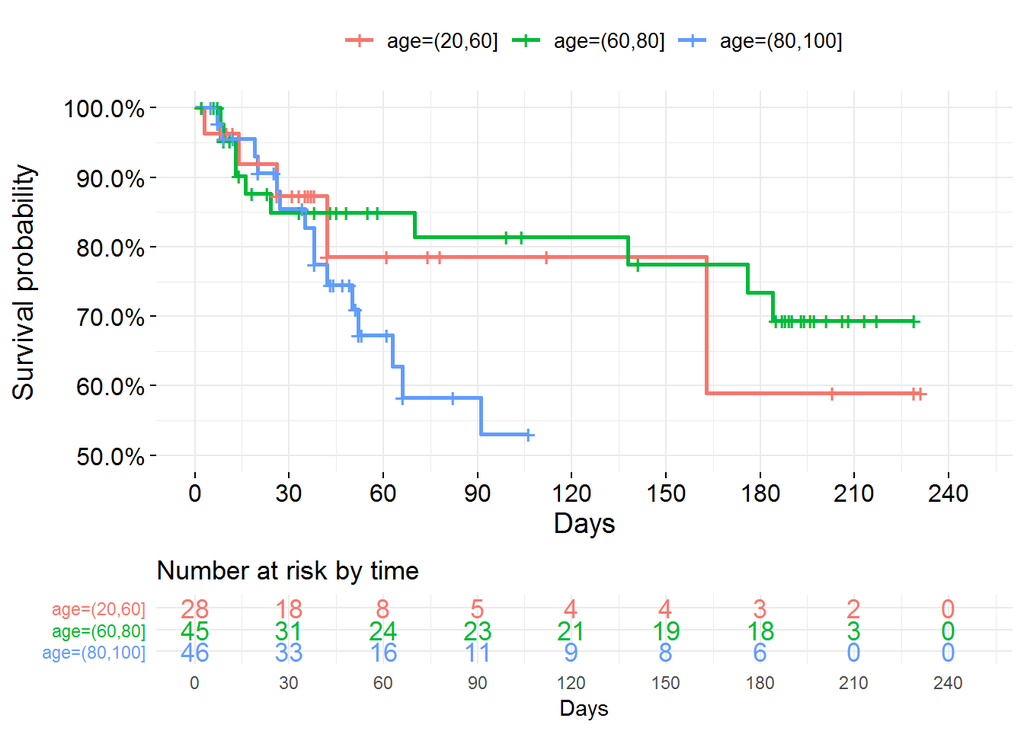

```r
group_same_clean$age <- cut(group_same_clean$cadast_idade_anos, c(20,60,80,100))

icc.fit<- survfit(Surv(group_same_clean$dias_vivo, group_same_clean$censored)~group_same_clean$age,
                  data= group_same_clean)

ggsurvplot(icc.fit, fun = NULL, color = "strata", palette =  "hue", linetype = 1,
           break.x.by = 30, surv.scale = c("percent"),
           conf.int = FALSE, conf.int.fill = "strata", censor = TRUE, pval = TRUE,
           pval.size = TRUE, pval.coord = c(NULL, NULL), main = "Congestive Heart Failure Survival" ,
           xlab = "Days", ylab = "Survival probability", font.main = c(16, "plain", "black"),
           font.x = c(14, "plain", "black"), font.y = c(14, "plain", "black"),
           font.tickslab = c(12, "plain", "black"), xlim = c(0,248), ylim = c(0.5,1.0),
           legend = c("top"), legend.title = " ",
           legend.labs = NULL, font.legend = c(10, "plain", "black"), risk.table = TRUE,
           risk.table.title = "Number at risk by time", risk.table.col = "strata",
           risk.table.fontsize = 4.5, risk.table.y.text = TRUE, risk.table.y.text.col = TRUE,
           risk.table.height = 0.25, surv.plot.height = 0.75, ggtheme = theme_minimal())
```

## 2. Organizing data to fit in Surv()

To plot a Kaplan-Meier curve few information is required. It is the number of days in trial, a variable indicating whether the patient reached the event of interest (censored) and maybe a variable to stratify the sample (age, gender, comorbidities, etc).

```
##   censored dias_vivo      age
## 2        0   38 days (80,100]
## 3        0  106 days (80,100]
## 4        1   52 days (80,100]
## 5        0    5 days (80,100]
## 6        0   25 days (80,100]
## 7        1   26 days (80,100]
```